# Lab 6

Author

Nicholas Le

```python
import pandas as pd
import numpy as np
from sklearn.pipeline import Pipeline
from sklearn.compose import make_column_selector, ColumnTransformer
from sklearn.preprocessing import StandardScaler, OneHotEncoder, PolynomialFeatures
from sklearn.metrics import r2_score
from sklearn.model_selection import GridSearchCV, KFold
from sklearn.linear_model import LinearRegression, Ridge, Lasso, ElasticNet
from sklearn.model_selection import train_test_split, cross_val_score
from plotnine import *
import warnings

warnings.filterwarnings("ignore")
```

```python
myData = pd.read_csv(r"C:\Users\2003n\Desktop\GradClasses Laptop\Hitters.csv")
myData.head(5)
myData.isna().sum()
```

```
AtBat         0
Hits          0
HmRun         0
Runs          0
RBI           0
Walks         0
Years         0
CAtBat        0
CHits         0
CHmRun        0
CRuns         0
CRBI          0
CWalks        0
League        0
Division      0
PutOuts       0
Assists       0
Errors        0
Salary       59
NewLeague     0
dtype: int64
```

```python
myData = myData.dropna()
myData = pd.get_dummies(myData, columns=["League", "Division", "NewLeague"], drop_first=True)
x = myData.drop(["Salary"],axis = 1)
y = myData["Salary"]
```

Part 1: Different Model Specs A. Regression without regularization

```python
preprocessing = ColumnTransformer(
    transformers=[], remainder ="passthrough"
)

ols_pipe = Pipeline([
    ("preprocessing", preprocessing),
    ("linear regression", LinearRegression())
])
ols_pipe.fit(x,y)

coefficients = ols_pipe.named_steps["linear regression"].coef_
ols_coeftable = (
    pd.Series(coefficients, index=x.columns, name = "coefficient").sort_values(key=np.abs,ascending = False)

)
ols_coeftable.head(10)
```

```
Division_W    -116.849246
League_N        62.599423
NewLeague_N    -24.762325
Hits             7.500768
Walks            6.231286
HmRun            4.330883
Years           -3.489054
Errors          -3.360760
Runs            -2.376210
AtBat           -1.979873
Name: coefficient, dtype: float64
```

```python
mse = -cross_val_score(ols_pipe, x, y, cv = 5, scoring= "neg_mean_squared_error")

print("Average Cross Validation MSE:",mse.mean())
```

```
Average Cross Validation MSE: 121136.31031816879
```

The OLS model MSE is approximately 121136 for salary when predicting the salaries of players in 1989. The coeffcients show that Division_W players tend to have a lower salary than the Eastern division. The number of Hits, Walks, and HmRuns positively contribute towards a players salary. Just looking at Hits, each hit is estiamted to created a players salary by about 7500. Looking at always, each walk shows about a 6231 increase in salary. Looking at HmRuns, each home run can see the player make about a 4330 increase in salary.

B. Ridge regression

```python
#Penalized Pipelines
def create_penalized_pipeline (model, x):
    dummy= [c for c in x.columns if c.startswith(("League", "Division", "NewLeague"))]
    numeric = [c for c in x.columns if c not in dummy]

    preprocessing = ColumnTransformer(
        transformers=[("scale_numeric", StandardScaler(),numeric)], remainder= "passthrough"
    )
    pipe = Pipeline([
        ("preprocessing", preprocessing),
        ("model", model)
    ])
    return pipe, numeric, dummy
```

```python
r_pipe, numeric_col, dummy_col = create_penalized_pipeline(Ridge(),x)


param = {"model__alpha": [0.01, 0.1, 1, 10, 100, 1000]}
cv = KFold(5, shuffle = True, random_state = 321)
ridge_gscv = GridSearchCV(
    estimator = r_pipe, param_grid = param, scoring = "neg_mean_squared_error",
    cv = cv, refit = True
)

ridge_gscv.fit(x,y)
```

```
GridSearchCV(cv=KFold(n_splits=5, random_state=321, shuffle=True),
             estimator=Pipeline(steps=[('preprocessing',
                                        ColumnTransformer(remainder='passthrough',
                                                          transformers=[('scale_numeric',
                                                                         StandardScaler(),
                                                                         ['AtBat',
                                                                          'Hits',
                                                                          'HmRun',
                                                                          'Runs',
                                                                          'RBI',
                                                                          'Walks',
                                                                          'Years',
                                                                          'CAtBat',
                                                                          'CHits',
                                                                          'CHmRun',
                                                                          'CRuns',
                                                                          'CRBI',
                                                                          'CWalks',
                                                                          'PutOuts',
                                                                          'Assists',
                                                                          'Errors'])])),
                                       ('model', Ridge())]),
             param_grid={'model__alpha': [0.01, 0.1, 1, 10, 100, 1000]},
             scoring='neg_mean_squared_error')
```

```python
best_alpha = ridge_gscv.best_params_["model__alpha"]
best_mse = -ridge_gscv.best_score_
print("Best Alpha:", best_alpha)
print("Best MSE:", best_mse)
```

```
Best Alpha: 10
Best MSE: 121496.63821488153
```

```python
Ridge_Final, numeric_col, dummy_col = create_penalized_pipeline(Ridge(alpha = 1),x)
Ridge_Final.fit(x,y)

r_coefs = Ridge_Final.named_steps["model"].coef_

feature_order = numeric_col + dummy_col

r_coeftable = pd.Series(r_coefs, index = feature_order).sort_values(key=np.abs,ascending = False)
print(r_coeftable)
```

```
CRuns          320.802717
Hits           296.801967
AtBat         -271.088165
CAtBat        -225.511649
CWalks        -184.289408
CRBI           160.409497
CHits          126.210585
Walks          124.344012
Division_W    -119.076927
PutOuts         78.651037
League_N        58.555947
Assists         47.493631
CHmRun          39.055346
Years          -38.619131
Runs           -29.212352
NewLeague_N    -24.027205
Errors         -23.651303
HmRun           17.973971
RBI             -8.909304
dtype: float64
```

The most significat coefficients for a positive relationship seem to be CRuns and Hits, which shows that more hits/CRUns generate a significant increase in salary. However AtBat and CaBat seem to not greatly contribute to salary increase, since its negative. It is also seen here that Division_W players still see a lower pay than East

```python
mse = -cross_val_score(Ridge_Final, x, y, cv = 5, scoring= "neg_mean_squared_error")

print("Average Cross Validation MSE:",mse.mean())
```

```
Average Cross Validation MSE: 119034.33271954535
```

C. Lasso Regression

```python
l_pipe, numeric_col, dummy_col = create_penalized_pipeline(Lasso(max_iter = 10000),x)
param = {"model__alpha": [0.01, 0.1, 1, 10, 100, 1000]}
cv = KFold(5, shuffle = True, random_state = 321)

lasso_gscv = GridSearchCV(
    estimator = l_pipe, param_grid = param, scoring = "neg_mean_squared_error",
    cv = cv, refit= True
)

lasso_gscv.fit(x, y)
```

```
GridSearchCV(cv=KFold(n_splits=5, random_state=321, shuffle=True),
             estimator=Pipeline(steps=[('preprocessing',
                                        ColumnTransformer(remainder='passthrough',
                                                          transformers=[('scale_numeric',
                                                                         StandardScaler(),
                                                                         ['AtBat',
                                                                          'Hits',
                                                                          'HmRun',
                                                                          'Runs',
                                                                          'RBI',
                                                                          'Walks',
                                                                          'Years',
                                                                          'CAtBat',
                                                                          'CHits',
                                                                          'CHmRun',
                                                                          'CRuns',
                                                                          'CRBI',
                                                                          'CWalks',
                                                                          'PutOuts',
                                                                          'Assists',
                                                                          'Errors'])])),
                                       ('model', Lasso(max_iter=10000))]),
             param_grid={'model__alpha': [0.01, 0.1, 1, 10, 100, 1000]},
             scoring='neg_mean_squared_error')
```

```python
best_alpha = lasso_gscv.best_params_["model__alpha"]
best_mse = -lasso_gscv.best_score_
print("Best Alpha:", best_alpha)
print("Best MSE:", best_mse)
```

```
Best Alpha: 1
Best MSE: 122829.70779279449
```

```python
Lasso_Final, numeric_col, dummy_col = create_penalized_pipeline(
    Lasso(alpha=best_alpha,max_iter=10000),x
)
Lasso_Final.fit(x,y)

l_coefs = Lasso_Final.named_steps["model"].coef_

feature_order = numeric_col + dummy_col

l_coeftable = pd.Series(l_coefs, index = feature_order).sort_values(key=np.abs,ascending = False)
print(l_coeftable)
```

```
CRuns          375.565034
Hits           304.358267
AtBat         -282.369623
CRBI           192.616442
CWalks        -189.643123
CAtBat        -162.644108
Walks          120.694778
Division_W    -114.412953
PutOuts         78.760260
Assists         41.996661
League_N        35.826079
Years          -34.947507
Runs           -24.966048
Errors         -18.479421
CHmRun          14.222855
HmRun           11.127146
RBI             -0.000000
CHits            0.000000
NewLeague_N     -0.000000
dtype: float64
```

Here CRuns and Hits have the most positive relationship to Salary compared to other coefficients. However, you can see that AtBat and CWalks are now negative, which shows that it does not have a strong impact on salary at all. Still Western Division players still see less pay contribution than East players.

```python
mse = -cross_val_score(Lasso_Final, x, y, cv = 5, scoring= "neg_mean_squared_error")

print("Average Cross Validation MSE:",mse.mean())
```

```
Average Cross Validation MSE: 119758.22781528858
```

The Lasso model produces an MSE of 119758.22 when predicting player salares for 1989, which is an improvement of the OLS model. This is with an alpha of 1.

D. Elastic Net

```python
en_pipe, numeric_col, dummy_col = create_penalized_pipeline(ElasticNet(max_iter=10000, random_state=321),x
)

param = {"model__alpha": [0.01, 0.1, 1, 10, 100, 1000], "model__l1_ratio":[0.0,0.1, 0.25, 0.5, 0.75, 1.0]}
cv = KFold(5, shuffle = True, random_state = 321)

en_gscv = GridSearchCV(
    estimator = en_pipe, param_grid = param, scoring = "neg_mean_squared_error",
    cv = cv, refit= True
)

en_gscv.fit(x,y)
```

```
GridSearchCV(cv=KFold(n_splits=5, random_state=321, shuffle=True),
             estimator=Pipeline(steps=[('preprocessing',
                                        ColumnTransformer(remainder='passthrough',
                                                          transformers=[('scale_numeric',
                                                                         StandardScaler(),
                                                                         ['AtBat',
                                                                          'Hits',
                                                                          'HmRun',
                                                                          'Runs',
                                                                          'RBI',
                                                                          'Walks',
                                                                          'Years',
                                                                          'CAtBat',
                                                                          'CHits',
                                                                          'CHmRun',
                                                                          'CRuns',
                                                                          'CRBI',
                                                                          'CWalks',
                                                                          'PutOuts',
                                                                          'Assists',
                                                                          'Errors'])])),
                                       ('model',
                                        ElasticNet(max_iter=10000,
                                                   random_state=321))]),
             param_grid={'model__alpha': [0.01, 0.1, 1, 10, 100, 1000],
                         'model__l1_ratio': [0.0, 0.1, 0.25, 0.5, 0.75, 1.0]},
             scoring='neg_mean_squared_error')
```

```python
best_alpha = en_gscv.best_params_["model__alpha"]
best_l1= en_gscv.best_params_["model__l1_ratio"]
best_mse = -en_gscv.best_score_
print("Best Alpha:", best_alpha)
print("Best L1 Ratio:", best_l1)
print("Best MSE:", best_mse)
```

```
Best Alpha: 0.1
Best L1 Ratio: 0.5
Best MSE: 121489.82976055502
```

```python
ElasticNet_Final, numeric_col, dummy_col = create_penalized_pipeline(
    ElasticNet(alpha=best_alpha,l1_ratio=best_l1,max_iter=10000),x
)
ElasticNet_Final.fit(x,y)

en_coefs = ElasticNet_Final.named_steps["model"].coef_

feature_order = numeric_col + dummy_col

en_coeftable = pd.Series(en_coefs, index = feature_order).sort_values(key=np.abs,ascending = False)
print(en_coeftable)
```

```
Hits           133.372258
AtBat         -111.954024
Division_W    -107.386320
CRuns          104.608445
CHits           88.655142
CRBI            86.237765
CWalks         -77.645082
Walks           75.529805
PutOuts         74.411159
CHmRun          56.841300
Years          -44.510216
League_N        35.836198
Assists         25.923810
Runs            25.858429
Errors         -24.026959
RBI             19.166809
HmRun          -12.365408
CAtBat          -7.926380
NewLeague_N     -3.431064
dtype: float64
```

The coefficients with the strongest positive relationship with Salary were Hits and CRuns, meaning more of them increases salary for players. Again you can see that AtBat and Division_W is negative indicating that they have a negative contribution to players salaries

```python
mse = -cross_val_score(ElasticNet_Final, x, y, cv = 5, scoring= "neg_mean_squared_error")

print("Average Cross Validation MSE:",mse.mean())
```

```
Average Cross Validation MSE: 119116.4733944472
```

With an MSE of 119116.47 for the Elastic Net Model (alpha 0.1, l of 0.5), the model was better than the OLS model.

Part II. Variable Selection

```python
lasso_abs = l_coeftable.abs().sort_values(ascending=False)
print(lasso_abs)
```

```
CRuns          375.565034
Hits           304.358267
AtBat          282.369623
CRBI           192.616442
CWalks         189.643123
CAtBat         162.644108
Walks          120.694778
Division_W     114.412953
PutOuts         78.760260
Assists         41.996661
League_N        35.826079
Years           34.947507
Runs            24.966048
Errors          18.479421
CHmRun          14.222855
HmRun           11.127146
RBI              0.000000
CHits            0.000000
NewLeague_N      0.000000
dtype: float64
```

Best Numeric: CRuns Top 5 Numeric: CRuns, Hits, AtBat, CRBI, CWalks Best Categorical: Division_W

```python
one_numeric = ["CRuns"]
five_numeric = ["CRuns","Hits", "AtBat", "CRBI", "CWalks"]
categorical = "Division_W"

myData2 = myData.copy()
for v in five_numeric:
    myData2[f"{v}:{categorical}"] = myData2[v]* myData2[categorical]

features = {"one numeric": one_numeric,"five numeric": five_numeric,
    "5 numeric + categorical inter": five_numeric + [categorical] +[f"{v}:{categorical}" for v in five_numeric],}

cv = KFold(5, shuffle = True, random_state = 321)
```

```python
def create_preprocessing(x):
    pre_scale =[col for col in x.columns if col.startswith(("League", "Division", "NewLeague")) or (":" in col) ] #gpt for assistance

    numeric =[col for col in x.columns if col not in  pre_scale]
    return ColumnTransformer([("scale_numeric",StandardScaler(), numeric)], remainder= "passthrough")

def model_compare(estimator, x, y, param_grid = None):
    pipe = Pipeline([("pre",create_preprocessing(x)),("model",estimator)])
    if param_grid is None:
        mse = -cross_val_score(pipe, x, y, cv = 5, scoring= "neg_mean_squared_error").mean()
        return mse, {}

    gridsearch = GridSearchCV(
            pipe, param_grid, scoring = "neg_mean_squared_error",cv = cv, refit = True
    )
    gridsearch.fit(x,y)
    return -gridsearch.best_score_,gridsearch.best_params_
```

```python
models={
    "OLS": (LinearRegression(),None),
    "Ridge": (Ridge(),{"model__alpha": [0.01, 0.1, 1, 10, 100, 1000]}),
    "Lasso": (Lasso(max_iter= 10000),{"model__alpha":[0.01, 0.1, 1, 10, 100, 1000]}),
    "Elastic Net": (ElasticNet(max_iter=10000,random_state=321), {
        "model__alpha": [0.01, 0.1, 1, 10, 100, 1000],
        "model__l1_ratio":[0.0,0.1, 0.25, 0.5, 0.75, 1.0]
    })
}

rows=[]
y2 = myData2["Salary"]

#help with gpt
for fs_name, cols in features.items():
    x2 = myData2[cols].copy()
    for mname, (estimate, grid) in models.items():
        mse, params = model_compare(estimate, x2, y2, grid)
        rows.append({"Features": fs_name, "Model":mname, "MSE": mse, "Best Parameters": params})

results = pd.DataFrame(rows).sort_values("MSE").reset_index(drop=True)

print(results)
```

```
                         Features        Model            MSE  \
0   5 numeric + categorical inter        Lasso  122832.242324
1   5 numeric + categorical inter  Elastic Net  122832.242324
2   5 numeric + categorical inter        Ridge  123584.853641
3                    five numeric          OLS  125502.852876
4                    five numeric  Elastic Net  125659.573685
5                    five numeric        Lasso  125659.573685
6                    five numeric        Ridge  125782.541247
7   5 numeric + categorical inter          OLS  132054.760135
8                     one numeric          OLS  143812.935916
9                     one numeric        Ridge  144579.762707
10                    one numeric  Elastic Net  144582.096990
11                    one numeric        Lasso  144666.396100

                                  Best Parameters
0                            {'model__alpha': 10}
1    {'model__alpha': 10, 'model__l1_ratio': 1.0}
2                            {'model__alpha': 10}
3                                              {}
4     {'model__alpha': 1, 'model__l1_ratio': 1.0}
5                             {'model__alpha': 1}
6                             {'model__alpha': 1}
7                                              {}
8                                              {}
9                            {'model__alpha': 10}
10  {'model__alpha': 0.1, 'model__l1_ratio': 0.5}
11                           {'model__alpha': 10}
```

Based on the results, the best configuration was Lasso Regression that used the five best numerical variables and categorical interactions with an alpha of 10. This because it had the lowest MSE of 122832.242324 compared to the others.

B. Lasso… The Lasso Model from Part 1 was not the same as from Lasso model from Part 2. This is due to the models using a different lambda, which also had a different MSE as well. This is because you use a different set of features/predictors, which would change the overall values.

Part IV. Final Model

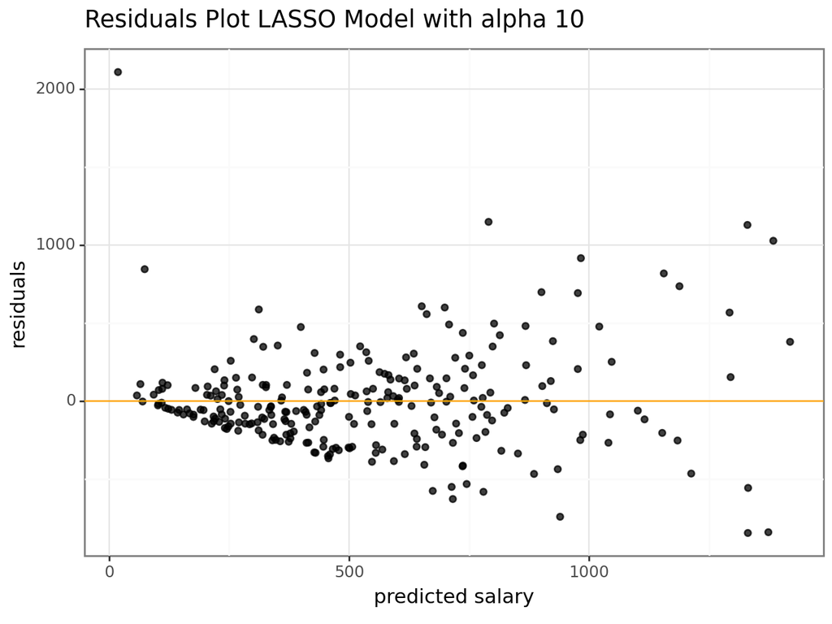

```python
x = myData.drop(columns=["Salary"]).copy()
y = myData["Salary"].copy()


FinalLassoModel, numeric_col, dummy_col = create_penalized_pipeline(Lasso(alpha=10, max_iter=10000),x)
FinalLassoModel.fit(x,y)

predict_y = FinalLassoModel.predict(x)

myData3 = myData.copy()
myData3["actual"] = y
myData3["predicted"] = predict_y
myData3["residuals"] = myData3["actual"]-myData3["predicted"]

(ggplot(myData3, aes(x="predicted",y="residuals"))
    +geom_point(alpha=.75)
    +geom_hline(yintercept = 0, color = "orange")
    +labs(title="Residuals Plot LASSO Model with alpha 10", x="predicted salary", y="residuals")
    +theme_bw()
)
```